# Customers EDA (Laura)

### 4. EDA

#### 4a. Where are the customers located?

I divided this question up into 3 sections: state, city, and zip code

```
   SP    RJ    MG    RS    PR    SC    BA    DF    ES    GO    PE    CE    PA
40800 12569 11375  5351  4928  3554  3314  2094  2008  1959  1630  1312   951
   MT    MA    MS    PB    PI    RN    AL    SE    TO    RO    AM    AC    AP
  891   730   700   523   486   476   407   343   275   242   146    79    68
   RR
   44
```

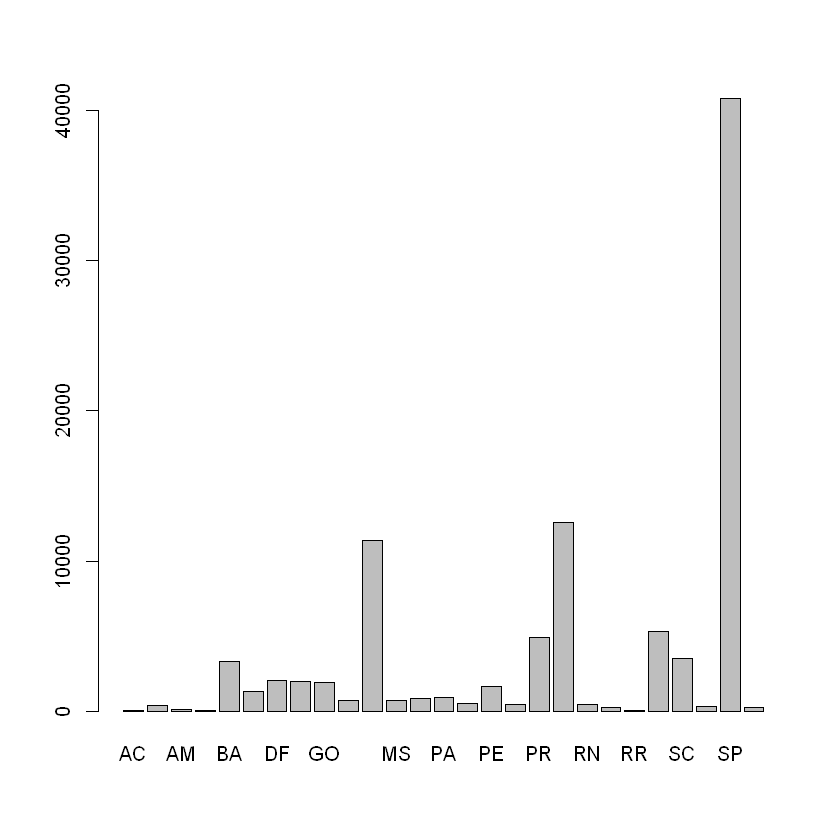

```r
#State
state_sales = data.table(table(cust_data2$customer_state))
names(state_sales) = c('Code', 'NumberOfSales')
sort(table(cust_data2$customer_state),decreasing = T)
barplot(table(cust_data2$customer_state))
```

Unsurprisingly, the three states with the highest population had the most sales. Sao Paulo, Rio de Janeiro, and Minas Gerais had the largest number of orders, respectively. There was a large drop-off between these 3 states and the rest.

A data.table: 27 × 2

| Code <chr> | sales_per_mil <dbl> |
| --- | --- |
| SP | 888.52014 |
| RJ | 728.00704 |
| DF | 694.46563 |
| MG | 537.34765 |
| ES | 499.67029 |
| SC | 496.03701 |
| RS | 470.32501 |
| PR | 430.99690 |
| GO | 279.12528 |
| MT | 255.70633 |
| MS | 251.89044 |
| BA | 222.81892 |
| TO | 174.84007 |
| PE | 170.55435 |
| SE | 149.21503 |
| PI | 148.47733 |
| CE | 143.66938 |
| RO | 136.16734 |
| RN | 135.73423 |
| PB | 130.16015 |
| AL | 121.95279 |
| PA | 110.54457 |
| MA | 103.17757 |
| AC | 89.57576 |
| AP | 80.40382 |
| RR | 72.63591 |
| AM | 35.22659 |

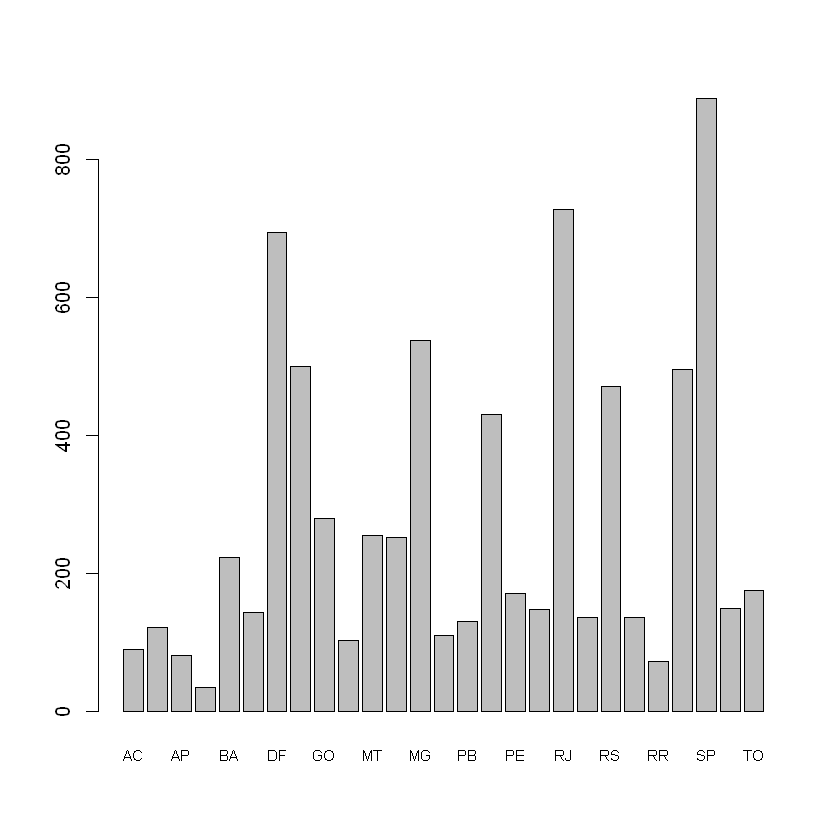

```r
brazil = left_join(brazil, state_sales, by ='Code')
brazil = mutate(brazil,sales_per_mil = NumberOfSales/Population*1000000)
state_sales_table = brazil %>%
  select(Code, sales_per_mil)
barplot(state_sales_table$sales_per_mil, names.arg = state_sales_table$Code,
        cex.names = .75)
state_sales_table[order(-sales_per_mil),]
```

I also made a graph of the sales on a per capita basis. Sao Paulo and Rio de Janeiro were still in the top 2, but the Distrito Federal, a relatively small state, jumped into the top 3. A cluster of 5 other states, including Minas Gerais, was right below those 3.

```r
#City
top_paying = cust_data2[transaction_price >0] %>%
  group_by(customer_city, customer_state) %>%
  summarize(Amt_Money = sum(transaction_price))
head(top_paying[order(-top_paying$Amt_Money),],10) #top 10 cities by amount paid
most_buying = cust_data2[Total_products_bought > 5] %>% #list of the number of products bought by city
  group_by(customer_state, customer_city) %>%
  summarize(result = sum(Total_products_bought))
head(most_buying[order(-most_buying$result),],10) #top 10 cities by number of sales
```

A grouped_df: 10 × 3

| customer_city <chr> | customer_state <chr> | Amt_Money <dbl> |
| --- | --- | --- |
| sao paulo | SP | 1761100.9 |
| rio de janeiro | RJ | 907482.7 |
| belo horizonte | MG | 331496.2 |
| brasilia | DF | 284772.0 |
| curitiba | PR | 194021.6 |
| campinas | SP | 174552.5 |
| porto alegre | RS | 169579.6 |
| salvador | BA | 163287.1 |
| guarulhos | SP | 132973.2 |
| niteroi | RJ | 109709.1 |

A grouped_df: 10 × 3

| customer_state <chr> | customer_city <chr> | result <dbl> |
| --- | --- | --- |
| SP | sao paulo | 557 |
| RJ | rio de janeiro | 190 |
| DF | brasilia | 90 |
| MG | belo horizonte | 69 |
| SP | campinas | 49 |
| RS | porto alegre | 48 |
| PR | curitiba | 44 |
| MT | cuiaba | 43 |
| SP | ipua | 41 |
| SP | santos | 38 |

The top 4 cities were Sao Paulo, Rio de Janeiro, Belo Horizonte, and Brasilia. Brasilia is in the Distrito Federal, which explains why that state had such a high per capita. Belo Horizonte is in Minas Gerais. These are four out of the six most populous cities in Brazil. One potential city for improvement is Fortaleza, which is the fifth most populated city in Brazil, but isnât anywhere in the top 10 of sales.

```r
#Zip Code
zip_codes = data.table(table(cust_data2$customer_zip_code_prefix))
names(zip_codes) = c('customer_zip_code_prefix', 'N')
zip_codes = zip_codes[order(-zip_codes$N)]
top_10_zip_codes = head(zip_codes, 10); top_10_zip_codes
top_10_zip_codes$customer_zip_code_prefix = as.numeric((top_10_zip_codes$customer_zip_code_prefix))
```

A data.table: 10 × 2

| customer_zip_code_prefix <chr> | N <int> |
| --- | --- |
| 22790 | 140 |
| 22793 | 119 |
| 24220 | 119 |
| 24230 | 114 |
| 22775 | 106 |
| 29101 | 101 |
| 35162 | 92 |
| 13212 | 91 |
| 22631 | 87 |
| 36570 | 83 |

There were too many zip codes to make a histogram of, so I looked at the top 10 zip codes. The top 5 were all in Rio de Janeiro, in fact, Rio had 6 of the top 10 zip codes. The others were in Espirito Santo, Minas Gerais (twice), and Sao Paulo.

#### 4b. What type of areas are the zip codes in?

I had to do this manually. I looked up a couple of the top 10 zip codes. Most of the zip codes in Rio (22790, 22793, 22775, and 22631) are from around the Barra de Tijuca, which seems to be an upscale living area. Two others from Rio (24220 and 24230) are from the Guanabara Bay, near Icarai, a beach area.

##### 4c. How many are returning customers?

Initially I did an analysis based on the customer ID. I counted how many times each customer ID showed up in the data (see section 2 - Initial EDA)

```r
cust_data2[duplicated(customer_id),]
```

A data.table: 0 × 19

| order_id | Total_products_bought | transaction_price | V1 | customer_id | customer_unique_id | customer_zip_code_prefix | customer_city | customer_state | order_estimated_delivery_date | order_purchase_date | order_delivered_date | seller_id | price | freight_value | payment_value | seller_zip_code_prefix | seller_city | seller_state |
| --- | --- | --- | --- | --- | --- | --- | --- | --- | --- | --- | --- | --- | --- | --- | --- | --- | --- | --- |
| <chr> | <dbl> | <dbl> | <int> | <chr> | <chr> | <int> | <chr> | <chr> | <date> | <date> | <date> | <chr> | <dbl> | <dbl> | <dbl> | <int> | <chr> | <chr> |

#### 4d. Who are the customers that haven't purchased in the longest time?

```r
cust_data2[order_purchase_date == '2017-09-09']
```

A data.table: 103 × 19

| order_id <chr> | Total_products_bought <dbl> | transaction_price <dbl> | V1 <int> | customer_id <chr> | customer_unique_id <chr> | customer_zip_code_prefix <int> | customer_city <chr> | customer_state <chr> | order_estimated_delivery_date <date> | order_purchase_date <date> | order_delivered_date <date> | seller_id <chr> | price <dbl> | freight_value <dbl> | payment_value <dbl> | seller_zip_code_prefix <int> | seller_city <chr> | seller_state <chr> |
| --- | --- | --- | --- | --- | --- | --- | --- | --- | --- | --- | --- | --- | --- | --- | --- | --- | --- | --- |
| 01500f2503fa84279982d9d87750021a | 1 | 19.90 | 68010 | 084064d0e425f87b49643992a88c2b43 | 1f4dd20e59017acccdc1888bd80fd381 | 13080 | campinas | SP | 2017-09-27 | 2017-09-09 | 2017-09-14 | 3d871de0142ce09b7081e2b9d1733cb1 | 19.90 | 12.69 | 32.59 | 13232 | campo limpo paulista | SP |
| 01c22546c4f9914e232006df82d96e0f | 1 | 17.90 | 100911 | 2269aa9a9e0847496cf2a7c2d86ad59b | b7f06c191c30297630e3b2771ff19e26 | 91760 | porto alegre | RS | 2017-09-28 | 2017-09-09 | 2017-09-21 | 128639473a139ac0f3e5f5ade55873a5 | 17.90 | 15.10 | 33.00 | 87050 | maringa | PR |
| 0692bac30867d1bf96c14aadbff1cf17 | 1 | 35.00 | 65004 | c5db75451fbf381870054e426b6863bd | 5be8242f4f7ca2f0bd389c867a889f0f | 1455 | sao paulo | SP | 2017-09-21 | 2017-09-09 | 2017-09-13 | b2eecf5ea250510da76590ca79d60e5d | 35.00 | 8.72 | 43.72 | 3318 | sao paulo | SP |
| 0961e67affdacb23a647b67618e2bc70 | 1 | 229.00 | 3404 | 1e98ef30dc6e4aebf3cedcf0bc5abeff | 35c343f49cd9c4ef07b58a8e551d646e | 28770 | santa maria madalena | RJ | 2017-10-05 | 2017-09-09 | 2017-09-18 | 1025f0e2d44d7041d6cf58b6550e0bfa | 229.00 | 54.20 | 283.20 | 3204 | sao paulo | SP |
| 09ff646bb8e18894b907e5b76f5fca59 | 1 | 52.64 | 40512 | 08ba3f633e08284c827e14b9700d8949 | be33152ae3eb53008fdba8c5efa40ab7 | 7950 | francisco morato | SP | 2017-09-27 | 2017-09-09 | 2017-09-20 | cca3071e3e9bb7d12640c9fbe2301306 | 52.64 | 11.87 | 64.51 | 14940 | ibitinga | SP |
| 0c51264bdcbe5893081232bba640dba0 | 1 | 78.00 | 3004 | db2bde8c137c06bd2b2f616b27414304 | 7168de2966ec5d0e040be29141e98aa2 | 37805 | juruaia | MG | 2017-10-03 | 2017-09-09 | 2017-09-15 | 1025f0e2d44d7041d6cf58b6550e0bfa | 78.00 | 16.31 | 94.31 | 3204 | sao paulo | SP |
| 0e905ed8f17c6568a12cad104c041e34 | 1 | 45.95 | 42136 | 7e6a2c82f870d4169d3cd945fcacee60 | d497d6d20e5cf4baf00922c695e9b8c2 | 25251 | duque de caxias | RJ | 2017-10-04 | 2017-09-09 | 2017-09-25 | 391fc6631aebcf3004804e51b40bcf1e | 45.95 | 15.10 | 61.05 | 14940 | ibitinga | SP |
| 0f503b220e9d1fd78562e41a427a0c6a | 1 | 459.90 | 78061 | 3810ae52bde69bed0acd162b5c18aadb | 0beec065ce2d16d3a8dbb22b87cf4c43 | 22631 | rio de janeiro | RJ | 2017-10-02 | 2017-09-09 | 2017-10-06 | 94144541854e298c2d976cb893b81343 | 459.90 | 20.50 | 480.40 | 94451 | viamao | RS |
| 1337d5367a799babc13f9f71c63bf7ab | 1 | 29.90 | 104825 | 84bf6a4346118c8306d16b593c15176e | 15823b5826557e80b07c3d5dc611568e | 21330 | rio de janeiro | RJ | 2017-09-27 | 2017-09-09 | 2017-09-19 | 4992e76a42cb3aad7a7047e0d3d7e729 | 29.90 | 14.10 | 44.00 | 3334 | sao paulo | SP |
| 18bfcd3049f8effbdf7a7e9b11d07f38 | 1 | 39.90 | 65523 | 7b7d601e3afe9a8b3671f05c5feab78a | f3da06e0291a73f2ae7d40029c91fc09 | 65200 | pinheiro | MA | 2017-10-03 | 2017-09-09 | 2017-09-26 | fc906263ca5083d09dce42fe02247800 | 39.90 | 34.15 | 74.05 | 31030 | belo horizonte | MG |
| 194e7b03e4469b2bcc7ba3c353077252 | 1 | 40.50 | 105893 | 2e8bfe5a56818eccb5017d88820db31f | 7c1b664bbfb23001b560f3fbcb49b8ae | 22210 | rio de janeiro | RJ | 2017-09-27 | 2017-09-09 | 2017-09-18 | 282f23a9769b2690c5dda22e316f9941 | 40.50 | 14.10 | 54.60 | 31573 | belo horizonte | MG |
| 19e99767938cf9c5969b4b00d1eaeaca | 1 | 44.00 | 83567 | 7c2f7ea28703035aea1c82509403b40b | 3dfa33e5348bd90b234a96f7294016d5 | 4814 | sao paulo | SP | 2017-09-21 | 2017-09-09 | 2017-09-14 | 2709af9587499e95e803a6498a5a56e9 | 44.00 | 7.78 | 51.78 | 3813 | sao paulo | SP |
| 19fe6cd13dca5943f17abd2c37c46abd | 1 | 89.99 | 72894 | ee2cb1f148f1e7ac8293287c6c8b1d0a | 1803287d1e7138aec6ea9d3c963ed87d | 8557 | poa | SP | 2017-09-25 | 2017-09-09 | 2017-09-14 | cc419e0650a3c5ba77189a1882b7556a | 89.99 | 7.88 | 97.87 | 9015 | santo andre | SP |
| 1a64643317da0457d3f145fab8734b22 | 1 | 58.99 | 73565 | 0d2aa9f205cc47cd8ffcfe0f43499f2e | 7b32049d8495d56c8b27eae575921a60 | 50940 | recife | PE | 2017-10-05 | 2017-09-09 | 2017-09-21 | cc419e0650a3c5ba77189a1882b7556a | 58.99 | 20.81 | 79.80 | 9015 | santo andre | SP |
| 1db48820d18841e3330e5721352b9387 | 1 | 94.00 | 50404 | b09883a38c50f6a64741985bd80ec237 | 9405bac2dd4fb1e31253f5c7f2711f42 | 65760 | presidente dutra | MA | 2017-10-05 | 2017-09-09 | 2017-09-26 | bfd27a966d91cfaafdb25d076585f0da | 94.00 | 35.98 | 129.98 | 13930 | serra negra | SP |
| 1f40c568147d792b8ff628f54803a6f2 | 1 | 49.95 | 53874 | 99788ef4e91b5e9d8771b66a49441984 | f012d0428d09708815ca563418f16d71 | 11717 | praia grande | SP | 2017-10-04 | 2017-09-09 | 2017-09-14 | 4e922959ae960d389249c378d1c939f5 | 49.95 | 11.85 | 61.80 | 12327 | jacarei | SP |
| 1f643298de39c374e3ad4e4838d156c1 | 1 | 37.80 | 81085 | 7c5dee768f1dfbea5ba80fd468040c19 | 6a72e79e17a6747650c71f55887a4ffa | 4447 | sao paulo | SP | 2017-09-21 | 2017-09-09 | 2017-09-14 | 093805f8f2aeb63881444571e1f48f30 | 37.80 | 8.72 | 46.52 | 6236 | osasco | SP |
| 216237ddbe1a6f6a13a749e580ccf469 | 1 | 180.00 | 43912 | aeda955c84b2a855165c2049b66b447f | a621c2c0af1dd7269c1ce20602f1bf9d | 44050 | feira de santana | BA | 2017-10-05 | 2017-09-09 | 2017-10-04 | 37be5a7c751166fbc5f8ccba4119e043 | 180.00 | 28.64 | 208.64 | 4248 | sao paulo | SP |
| 23923af7b4df1da5db096c921e728325 | 1 | 15.00 | 58379 | 6331b4b146b9f298fef30a6cdb08432a | c97b2ed8143afc4bd58d278bab98637b | 15804 | catanduva | SP | 2017-09-28 | 2017-09-09 | 2017-09-14 | ce27a3cc3c8cc1ea79d11e561e9bebb6 | 15.00 | 11.85 | 26.85 | 3006 | sao paulo | SP |
| 250fc7597b92f3bb967c2c0a6bd70e1b | 1 | 60.00 | 17182 | dfadcb615c5579faa9613dde872fa694 | 2e471b8b0ebd8aeb029d78917c3961d0 | 4346 | sao paulo | SP | 2017-09-21 | 2017-09-09 | 2017-09-13 | 955fee9216a65b617aa5c0531780ce60 | 60.00 | 8.72 | 68.72 | 4782 | sao paulo | SP |
| 2683346722c6565c6c79e08c8264f25f | 1 | 88.90 | 44760 | 2a7ba63c9e507356e5670b795ed56a18 | 24cad6db9c734bd4f0edc6a314735880 | 30620 | belo horizonte | MG | 2017-09-28 | 2017-09-09 | 2017-09-19 | cfb1a033743668a192316f3c6d1d2671 | 88.90 | 17.87 | 106.77 | 18110 | votorantim | SP |
| 27a6325c93e53bfae0a9b94bc263293f | 1 | 498.00 | 72171 | 7c2e9dc6dc40a13459ac05fcfddf0639 | dd0ee11726c7c81c39e8f00e0aef3e16 | 13211 | jundiai | SP | 2017-10-03 | 2017-09-09 | 2017-09-20 | 744dac408745240a2c2528fb1b6028f3 | 498.00 | 18.25 | 516.25 | 83408 | colombo | PR |
| 2f7a7c29354db7353c1887d24ae76636 | 1 | 270.00 | 109776 | a87364c569a01ec4d292805aef727137 | e8db9c7662675885007923d3eeb58972 | 7859 | franco da rocha | SP | 2017-10-04 | 2017-09-09 | 2017-09-18 | b372ee768ed69e46ca8cdbd267aa7a38 | 270.00 | 13.39 | 283.39 | 15013 | sao jose do rio preto | SP |
| 3474c37ad7067402582a2852a08015f7 | 1 | 649.99 | 68234 | 85bb769857d427c1ff461c9ae828c71b | 821033b010006f04e18cccbb9e096330 | 26220 | nova iguacu | RJ | 2017-09-28 | 2017-09-09 | 2017-09-19 | 7e93a43ef30c4f03f38b393420bc753a | 649.99 | 19.31 | 669.30 | 6429 | barueri | SP |
| 360b84029c125bb8d4ede52585f058f2 | 1 | 23.99 | 73230 | 22a62541ed4704ac4f51d175379222d7 | 1803287d1e7138aec6ea9d3c963ed87d | 8557 | poa | SP | 2017-09-26 | 2017-09-09 | 2017-09-14 | cc419e0650a3c5ba77189a1882b7556a | 23.99 | 7.78 | 31.77 | 9015 | santo andre | SP |
| 378d03578566e65bc195cc5296a31526 | 1 | 234.00 | 21545 | 06757bb75493151d0e73ce8e3bc32987 | 950756be397d0fc73e96b1a32287cd38 | 6825 | embu das artes | SP | 2017-09-27 | 2017-09-09 | 2017-09-13 | 440dd6ab244315c632130ecfb63827b1 | 234.00 | 14.66 | 248.66 | 15502 | votuporanga | SP |
| 382a2285603c57524f1b44601ade85c3 | 1 | 37.50 | 8315 | 1d44df4d54c74b1b8944e7c8816c1ec5 | 607bf4f7777e71000af8f7f5e8af7e15 | 22210 | rio de janeiro | RJ | 2017-09-28 | 2017-09-09 | 2017-09-18 | 6c7d50c24b3ccd2fd83b44d8bb34e073 | 37.50 | 17.60 | 55.10 | 19025 | presidente prudente | SP |
| 3ab37da4c3d273ccd8635987b4a6003e | 1 | 97.90 | 17534 | 053050ee241c66cf7b2c7d91926547bc | 30f1735f7cea347c2b5a9ece8353d6ef | 13423 | piracicaba | SP | 2017-10-09 | 2017-09-09 | 2017-09-18 | dbc22125167c298ef99da25668e1011f | 97.90 | 17.17 | 115.07 | 37564 | borda da mata | MG |
| 417a0034ecdc989212079f64368eccc9 | 1 | 45.00 | 98289 | e0c772c070d2fab11a4f61376b8e67d0 | 7e6eb9bf83bdbd58ac16b9f97f9c2afc | 3388 | sao paulo | SP | 2017-09-27 | 2017-09-09 | 2017-09-18 | 70a12e78e608ac31179aea7f8422044b | 45.00 | 11.85 | 56.85 | 12327 | jacarei | SP |
| 43b496a7732ace398ea4eb3bd520ab22 | 1 | 498.80 | 115629 | 41021cf729eff1a1ef1f51f09fa39bea | 9186963d441c85d9a781413da96a7fb8 | 65550 | sao bernardo | MA | 2017-10-04 | 2017-09-09 | 2017-09-18 | 1976a05ecf2996d6ffb7b5430e635fe7 | 498.80 | 171.50 | 670.30 | 19806 | assis | SP |
| ... | ... | ... | ... | ... | ... | ... | ... | ... | ... | ... | ... | ... | ... | ... | ... | ... | ... | ... |
| bcbb11b412d6f57c7a4a9b1d1ff56a13 | 1 | 52.37 | 29291 | 6921ebf2d8c510b659be8c8579fa7e66 | 38679f702b456bfcfdcad08d9b1293b0 | 6070 | osasco | SP | 2017-09-29 | 2017-09-09 | 2017-09-20 | ca3bd7cd9f149df75950150d010fe4a2 | 52.37 | 9.34 | 61.71 | 4361 | sao paulo | SP |
| bf7dc02ad247527a27900abb19306a3c | 3 | 39.98 | 10419 | 96d93b5cda637617dcceb8e7059b19c9 | 8ae3278d853e838e308cd77922061cfd | 60867 | fortaleza | CE | 2017-09-28 | 2017-09-09 | 2017-09-19 | e09887ca8c7bf8a4621ce481820414ef | 19.99 | 17.63 | 75.24 | 8431 | sao paulo | SP |
| bfaf4827cdd358e6cc443e44f9f9132f | 1 | 56.85 | 104710 | b6f1ce97a5c1317696905cc28a6a5857 | 1520ebe0915772d3bd92d082a1afdf06 | 20780 | rio de janeiro | RJ | 2017-09-28 | 2017-09-09 | 2017-09-18 | f45122a9ab94eb4f3f8953578bc0c560 | 56.85 | 15.15 | 72.00 | 13419 | piracicaba | SP |
| c13f7e0f6e68493d056654349be6c15b | 1 | 55.00 | 67542 | 1d185a1881211f40e281043cf723d455 | b4775480db52304d754446c219170341 | 6045 | osasco | SP | 2017-09-21 | 2017-09-09 | 2017-09-13 | 6560211a19b47992c3666cc44a7e94c0 | 55.00 | 7.78 | 62.78 | 5849 | sao paulo | SP |
| c2889b2085529be65218f712352769e6 | 1 | 54.90 | 48354 | fc5a45c75c8665a80c5d2b5ce7ad9f1d | a1536ec97fe9a328697c20c5c1581d69 | 6365 | carapicuiba | SP | 2017-09-27 | 2017-09-09 | 2017-09-13 | 3d871de0142ce09b7081e2b9d1733cb1 | 54.90 | 12.72 | 67.62 | 13232 | campo limpo paulista | SP |
| c39da54f19d2aa7b89667e4817f05629 | 1 | 15.00 | 58382 | 6df80b1b894bb87f1ec7ce6534db6152 | 26eaae8c1a6bf6dde7ec03d919b31ffd | 68633 | dom eliseu | PA | 2017-10-18 | 2017-09-09 | 2017-10-02 | ce27a3cc3c8cc1ea79d11e561e9bebb6 | 15.00 | 25.63 | 40.63 | 3006 | sao paulo | SP |
| c61e31d4cd0672fe89449ab560602519 | 1 | 45.90 | 2372 | a1937e26edb8cc57b903979f75291e8f | 76f96ad47604ec56b5d9c68148279587 | 92030 | canoas | RS | 2017-10-16 | 2017-09-09 | 2017-09-25 | cca3071e3e9bb7d12640c9fbe2301306 | 45.90 | 16.11 | 62.01 | 14940 | ibitinga | SP |
| c6e7a0810e0020963c7dc5ec9087c509 | 1 | 91.99 | 23448 | 9d02a1c6855b3536a26bec71750a7908 | 1bc2bf4a35e6709ec796ea88a946b66b | 38230 | fronteira | MG | 2017-10-02 | 2017-09-09 | 2017-09-20 | 385799a1cddbd26dfeb9157356a42282 | 91.99 | 15.39 | 107.38 | 4676 | sao paulo | SP |
| c785921c49242bfac499ee30c455154f | 1 | 65.00 | 12008 | 1234431d00a8ee163e2c58e7c699ff0c | 3e04d4a97b15031c0b6dc8ab7f574aee | 68590 | jacunda | PA | 2017-10-18 | 2017-09-09 | 2017-09-29 | b4ffb71f0cb1b1c3d63fad021ecf93e1 | 65.00 | 25.73 | 90.73 | 3880 | sao paulo | SP |
| ca5d34455321c329173e1c6c3fcff7f9 | 1 | 12.88 | 63364 | 21847e723748ace6cb588bef10844823 | 0f187f58097c5431d5244e1fe1383884 | 19360 | santo anastacio | SP | 2017-09-27 | 2017-09-09 | 2017-09-19 | 36a968b544695394e4e9d7572688598f | 12.88 | 11.85 | 24.73 | 11010 | santos | SP |
| cb61ea3467956c7b83c342c1cc488364 | 1 | 31.80 | 3478 | 682ada82d00f8a8f7c766f10b6f641dc | 2da5ee41ace2b004297ab83756b6639e | 78360 | campo novo do parecis | MT | 2017-10-09 | 2017-09-09 | 2017-10-03 | 1025f0e2d44d7041d6cf58b6550e0bfa | 31.80 | 17.92 | 99.44 | 3204 | sao paulo | SP |
| cd49d0987575fc21d96fb52e37b16191 | 1 | 85.00 | 33468 | 04c6985fb618f4fba64adf76dc2dc855 | d81e95c47defd78bd56894ce015396c2 | 40810 | salvador | BA | 2017-10-09 | 2017-09-09 | 2017-09-19 | b6d44737c043328708f6749c2dbe50bd | 85.00 | 22.46 | 107.46 | 9230 | santo andre | SP |
| cd4f9a974c6789b89069a844779294a2 | 1 | 315.00 | 97701 | 7bc9b7017eab15299f2e16233739e918 | 183098e8a2b68ad63794031d5b719d69 | 29056 | vitoria | ES | 2017-10-04 | 2017-09-09 | 2017-09-18 | 53243585a1d6dc2643021fd1853d8905 | 315.00 | 17.65 | 332.65 | 42738 | lauro de freitas | BA |
| d1543ed643aa74672a7cb5a650e3fcef | 1 | 99.99 | 14286 | f405c1508283b811894b6fdb085041cb | b37dc68ae94b5d9dab31d2358568d4bb | 4845 | sao paulo | SP | 2017-09-21 | 2017-09-09 | 2017-09-18 | bd697db56ff8e7c9cd1abeb7f72029b2 | 99.99 | 7.95 | 107.94 | 3533 | sao paulo | SP |
| d19b8c6b433223ffd798af28489ccc02 | 1 | 56.00 | 40656 | 66bf5445b228f0426252659775544d3b | 5a1b26f24321efd9bdd49dc98aed8384 | 11060 | santos | SP | 2017-09-27 | 2017-09-09 | 2017-09-18 | a3e9a2c700480d9bb01fba070ba80a0e | 56.00 | 13.41 | 138.82 | 14940 | ibitinga | SP |
| d2f43762a6f922b1bb1cc34a9563ad28 | 1 | 21.99 | 98834 | 6095d10fab2c63413029ac0a1aa7c7d0 | 0b12f11a86385b5ddea612161375ec68 | 22760 | rio de janeiro | RJ | 2017-10-04 | 2017-09-09 | 2017-09-18 | db4350fd57ae30082dec7acbaacc17f9 | 21.99 | 14.10 | 36.09 | 3126 | sao paulo | SP |
| d4068e9d72451b844cf7aae5bd7ec922 | 1 | 610.00 | 55097 | 681e334b8995206f1fc8ab3275d90592 | 4dc19e952235d15cda17a77f0476a7f7 | 3985 | sao paulo | SP | 2017-09-27 | 2017-09-09 | 2017-09-19 | 834f3294fba9f932f56edc879193f925 | 610.00 | 37.54 | 647.54 | 14808 | araraquara | SP |
| d46d30516947c87bbcb5d6ce98da510c | 3 | 64.65 | 5470 | 9f882879a6fa0b1de2906aac483883de | 4279dc495a38ef8fb0ea0a9201c6ee30 | 90630 | porto alegre | RS | 2017-10-05 | 2017-09-09 | 2017-09-25 | 391fc6631aebcf3004804e51b40bcf1e | 24.75 | 11.04 | 97.35 | 14940 | ibitinga | SP |
| dd8df609ed4683bda8dd7515115f3b50 | 1 | 299.99 | 97562 | 123f593f6655a73fb519bbfc61f1336c | 528a2936af7562b17994a0d12962580b | 35170 | coronel fabriciano | MG | 2017-10-02 | 2017-09-09 | 2017-09-18 | 53243585a1d6dc2643021fd1853d8905 | 299.99 | 27.38 | 327.37 | 42738 | lauro de freitas | BA |
| de951feb6c754b2c61f0ed3c66569f4a | 1 | 990.00 | 80747 | 99ef3b28b2ab64bf0a00c2a5c9bafadd | 60055ae4e5bdcbf7d567809728def6ed | 1020 | sao paulo | SP | 2017-10-02 | 2017-09-09 | 2017-09-25 | 17f51e7198701186712e53a39c564617 | 990.00 | 87.41 | 2154.82 | 3908 | sao paulo | SP |
| e1d476e141862d870436d761b312032d | 1 | 49.00 | 45344 | 8eaef9eca5f384f13d08bdd90c07434f | 69e614f614a3716d949e7ffeb09afd5f | 21331 | rio de janeiro | RJ | 2017-09-28 | 2017-09-09 | 2017-09-25 | 2d50d6282f8aa2257819a77bfaa0efe0 | 49.00 | 16.11 | 65.11 | 14940 | ibitinga | SP |
| e484f4c3e8793e447052654990533c23 | 1 | 259.90 | 78099 | f35e64c823f62d46b6a6cab2d26f0a36 | c29988c75ec3c16f63c07d17cf612125 | 17502 | marilia | SP | 2017-10-06 | 2017-09-09 | 2017-09-22 | 94144541854e298c2d976cb893b81343 | 259.90 | 18.26 | 278.16 | 94451 | viamao | RS |
| e527fadf4133cb83320eba9c12a0db68 | 1 | 49.70 | 5408 | 77c5ac582cd8d2dbccc1c5faf6971de3 | 5dbaf31e6f3ccef2df173b8d09a07128 | 12285 | cacapava | SP | 2017-09-27 | 2017-09-09 | 2017-09-19 | 391fc6631aebcf3004804e51b40bcf1e | 49.70 | 13.37 | 63.07 | 14940 | ibitinga | SP |
| e8899387e52fb6a10ae971c69eb09bf5 | 1 | 79.90 | 51695 | 49ee772ae3757a7a5a306a582d2907a5 | 37b037bf83ac298b4fd1d8c2e96b7f26 | 51011 | recife | PE | 2017-10-04 | 2017-09-09 | 2017-09-20 | a49928bcdf77c55c6d6e05e09a9b4ca5 | 79.90 | 20.96 | 100.86 | 3017 | sao paulo | SP |
| e8ecb472cb1a0f18c82e2d358f8e2128 | 1 | 79.99 | 503 | e692f60b9b5fbb4b803fe58759387cdc | 47a2ef2c9978c0bfedfbcc2a1f722764 | 20735 | rio de janeiro | RJ | 2017-10-03 | 2017-09-09 | 2017-09-28 | 7c67e1448b00f6e969d365cea6b010ab | 79.99 | 36.22 | 116.21 | 8577 | itaquaquecetuba | SP |
| ec108f8c96f1037449cfb5e118d9a008 | 1 | 21.99 | 98572 | 88916d770ca6dcded91cec7ba0bb7406 | 13b3179dcf466fbfe762b4c4d774e6af | 60110 | fortaleza | CE | 2017-09-28 | 2017-09-09 | 2017-09-24 | ef506c96320abeedfb894c34db06f478 | 21.99 | 17.63 | 39.62 | 3569 | sao paulo | SP |
| f57d1c0df61322155f9afd92596de339 | 1 | 99.00 | 92657 | 1eff2b97ea85a4a43eb612a29a2c169f | c29153b4968032a063b623e74ecc48b0 | 13635 | pirassununga | SP | 2017-09-27 | 2017-09-09 | 2017-09-20 | 3d871de0142ce09b7081e2b9d1733cb1 | 99.00 | 13.71 | 112.71 | 13232 | campo limpo paulista | SP |
| f6974499820661b92dd1922750d6f0d0 | 1 | 49.90 | 8935 | 2b2d33994e74b6958e20bae94221c036 | 606a5bf59d47222df4bc2c3518dbbeb7 | 9111 | santo andre | SP | 2017-09-21 | 2017-09-09 | 2017-09-12 | 30a2f535bb48308f991d0b9ad4a8c4bb | 49.90 | 8.72 | 58.62 | 13457 | santa barbara d'oeste | SP |
| fc570e267c5c6bd72f926b1e075e9840 | 1 | 23.99 | 73123 | 4adfaba43ed62faa6b513a4b7623ebec | 79a1efe6acacf850e4aaf7d8bf7917c9 | 22070 | rio de janeiro | RJ | 2017-10-02 | 2017-09-09 | 2017-09-14 | cc419e0650a3c5ba77189a1882b7556a | 23.99 | 14.10 | 38.09 | 9015 | santo andre | SP |
| fccc01060b3a8f4c458f942871da6bd8 | 1 | 62.90 | 44647 | b9e25fb19734f55b6132644fb7dc447f | 24cad6db9c734bd4f0edc6a314735880 | 30620 | belo horizonte | MG | 2017-10-03 | 2017-09-09 | 2017-09-16 | 004c9cd9d87a3c30c522c48c4fc07416 | 62.90 | 17.69 | 80.59 | 14940 | ibitinga | SP |